# STAT100 - Compulsory Assignment 07 - Fabio Rodrigues Pereira

# OPPGAVE 3

```r
aar <- seq(1946,1950,by=1)
aar
```

```
[1] 1946 1947 1948 1949 1950
```

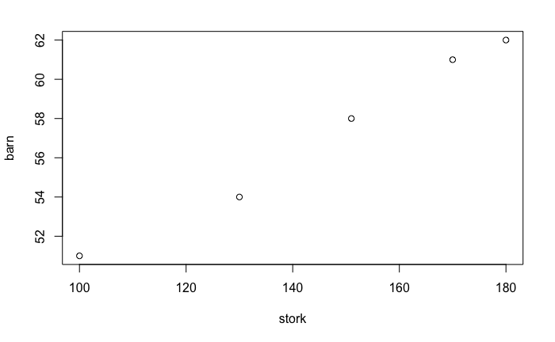

```r
stork <- c(100,130,151,170,180)
barn <- c(51,54,58,61,62)
plot(stork,barn)
```

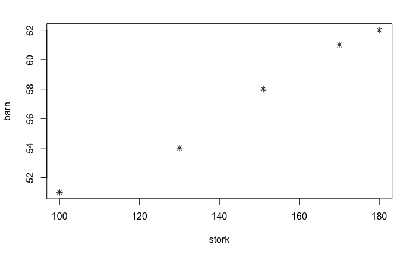

```r
plot(stork,barn,pch=8)
```

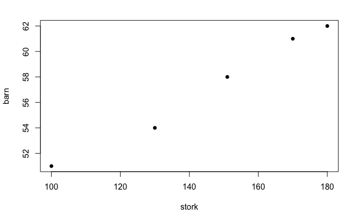

```r
plot(stork,barn,pch=16)
```

```r
cor(barn,stork)
```

```
[1] 0.9935716
```

```r
cor(barn,stork)
```

```
[1] 0.9935716
```

# Oppgave 4

# Last ned og last inn Body1 via File -> Open File…

# 4B)

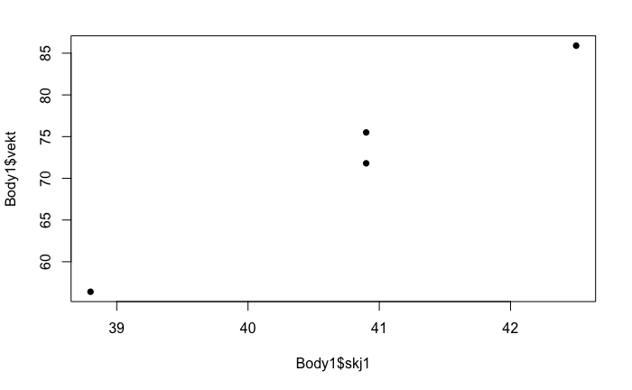

```r
plot(Body1$skj1,Body1$vekt,pch=16)
```

# OPPGAVE 4C)

```r
cor(Body1$skj1,Body1$vekt)
```

```
[1] 0.9920488
```

# OPPGAVE 4D)

# Folgende kommando setter sammen (binder sammen) (“column-binding”, leser jeg inni meg)

# kolonnene vekt og de 9 forste colonnene i Body1, som er de 9 skjelettvariablene:

```r
vekt_og_skjelett <- cbind(Body1$vekt,Body1[,1:9])
cor(vekt_og_skjelett)
```

```
           Body1$vekt      skj1      skj2      skj3      skj4      skj5      skj6      skj7
Body1$vekt  1.0000000 0.9920488 0.6703043 0.7124366 0.6667081 0.9247459 0.9458276 0.8223725
skj1        0.9920488 1.0000000 0.6177794 0.6609676 0.5806607 0.9188914 0.9455939 0.8002693
skj2        0.6703043 0.6177794 1.0000000 0.9982359 0.4446018 0.8589907 0.4077058 0.2419910
skj3        0.7124366 0.6609676 0.9982359 1.0000000 0.4809196 0.8827214 0.4610973 0.2977007
skj4        0.6667081 0.5806607 0.4446018 0.4809196 1.0000000 0.4646120 0.7146160 0.8382688
skj5        0.9247459 0.9188914 0.8589907 0.8827214 0.4646120 1.0000000 0.7538154 0.5477600
skj6        0.9458276 0.9455939 0.4077058 0.4610973 0.7146160 0.7538154 1.0000000 0.9480758
skj7        0.8223725 0.8002693 0.2419910 0.2977007 0.8382688 0.5477600 0.9480758 1.0000000
skj8        0.8755225 0.8367390 0.9453471 0.9628124 0.5897709 0.9632499 0.6819178 0.5226183
skj9        0.9261079 0.8885062 0.5246169 0.5727273 0.8819145 0.7429119 0.9549462 0.9528454
                skj8      skj9
Body1$vekt 0.8755225 0.9261079
skj1       0.8367390 0.8885062
skj2       0.9453471 0.5246169
skj3       0.9628124 0.5727273
skj4       0.5897709 0.8819145
skj5       0.9632499 0.7429119
skj6       0.6819178 0.9549462
skj7       0.5226183 0.9528454
skj8       1.0000000 0.7518213
skj9       0.7518213 1.0000000
```

# Gjor det samme, men med litt ferre desimaler (runder av til 2 desimaler etter komma)

```r
round(cor(vekt_og_skjelett),2)
```

```
           Body1$vekt skj1 skj2 skj3 skj4 skj5 skj6 skj7 skj8 skj9
Body1$vekt       1.00 0.99 0.67 0.71 0.67 0.92 0.95 0.82 0.88 0.93
skj1             0.99 1.00 0.62 0.66 0.58 0.92 0.95 0.80 0.84 0.89
skj2             0.67 0.62 1.00 1.00 0.44 0.86 0.41 0.24 0.95 0.52
skj3             0.71 0.66 1.00 1.00 0.48 0.88 0.46 0.30 0.96 0.57
skj4             0.67 0.58 0.44 0.48 1.00 0.46 0.71 0.84 0.59 0.88
skj5             0.92 0.92 0.86 0.88 0.46 1.00 0.75 0.55 0.96 0.74
skj6             0.95 0.95 0.41 0.46 0.71 0.75 1.00 0.95 0.68 0.95
skj7             0.82 0.80 0.24 0.30 0.84 0.55 0.95 1.00 0.52 0.95
skj8             0.88 0.84 0.95 0.96 0.59 0.96 0.68 0.52 1.00 0.75
skj9             0.93 0.89 0.52 0.57 0.88 0.74 0.95 0.95 0.75 1.00
```

# Gjor det samme for omkretsvariablene:

```r
vekt_og_omkrets <- cbind(Body1$vekt,Body1[,10:21])
cor(vekt_og_omkrets)
```

```
           Body1$vekt     omkr1     omkr2     omkr3     omkr4      omkr5        omkr6     omkr7
Body1$vekt  1.0000000 0.9558256 0.9346156 0.8895976 0.8510284 0.83308164  0.551450373 0.8283879
omkr1       0.9558256 1.0000000 0.9958147 0.7552347 0.6712218 0.64640037  0.481869436 0.9562079
omkr2       0.9346156 0.9958147 1.0000000 0.6960310 0.6123659 0.61586834  0.519292703 0.9713534
omkr3       0.8895976 0.7552347 0.6960310 1.0000000 0.9793834 0.83687973  0.275900995 0.5463686
omkr4       0.8510284 0.6712218 0.6123659 0.9793834 1.0000000 0.91192195  0.376379946 0.4282414
omkr5       0.8330816 0.6464004 0.6158683 0.8368797 0.9119219 1.00000000  0.713634963 0.4113120
omkr6       0.5514504 0.4818694 0.5192927 0.2759010 0.3763799 0.71363496  1.000000000 0.3953041
omkr7       0.8283879 0.9562079 0.9713534 0.5463686 0.4282414 0.41131196  0.395304081 1.0000000
omkr8       0.8426779 0.9602478 0.9790618 0.5431829 0.4394751 0.45750759  0.475541990 0.9959913
omkr9       0.8233991 0.8512174 0.8089491 0.8307792 0.7019824 0.46230907 -0.008961721 0.7885705
omkr10      0.8677000 0.9487398 0.9726805 0.5481088 0.4834397 0.57724233  0.651042038 0.9545333
omkr11      0.5767053 0.7181104 0.6957272 0.5188644 0.3360061 0.06499893 -0.250954481 0.7777228
omkr12      0.8589425 0.9277844 0.9041240 0.7630020 0.6288744 0.45294947  0.121887708 0.9039454
               omkr8        omkr9    omkr10      omkr11    omkr12
Body1$vekt 0.8426779  0.823399114 0.8677000  0.57670533 0.8589425
omkr1      0.9602478  0.851217411 0.9487398  0.71811036 0.9277844
omkr2      0.9790618  0.808949092 0.9726805  0.69572721 0.9041240
omkr3      0.5431829  0.830779186 0.5481088  0.51886445 0.7630020
omkr4      0.4394751  0.701982423 0.4834397  0.33600613 0.6288744
omkr5      0.4575076  0.462309072 0.5772423  0.06499893 0.4529495
omkr6      0.4755420 -0.008961721 0.6510420 -0.25095448 0.1218877
omkr7      0.9959913  0.788570549 0.9545333  0.77772281 0.9039454
omkr8      1.0000000  0.750183910 0.9771807  0.71915008 0.8746988
omkr9      0.7501839  1.000000000 0.6530156  0.90651750 0.9756046
omkr10     0.9771807  0.653015603 1.0000000  0.56258652 0.7893951
omkr11     0.7191501  0.906517502 0.5625865  1.00000000 0.9136083
omkr12     0.8746988  0.975604583 0.7893951  0.91360829 1.0000000
```

```r
round(cor(vekt_og_omkrets),2)
```

```
           Body1$vekt omkr1 omkr2 omkr3 omkr4 omkr5 omkr6 omkr7 omkr8 omkr9 omkr10 omkr11 omkr12
Body1$vekt       1.00  0.96  0.93  0.89  0.85  0.83  0.55  0.83  0.84  0.82   0.87   0.58   0.86
omkr1            0.96  1.00  1.00  0.76  0.67  0.65  0.48  0.96  0.96  0.85   0.95   0.72   0.93
omkr2            0.93  1.00  1.00  0.70  0.61  0.62  0.52  0.97  0.98  0.81   0.97   0.70   0.90
omkr3            0.89  0.76  0.70  1.00  0.98  0.84  0.28  0.55  0.54  0.83   0.55   0.52   0.76
omkr4            0.85  0.67  0.61  0.98  1.00  0.91  0.38  0.43  0.44  0.70   0.48   0.34   0.63
omkr5            0.83  0.65  0.62  0.84  0.91  1.00  0.71  0.41  0.46  0.46   0.58   0.06   0.45
omkr6            0.55  0.48  0.52  0.28  0.38  0.71  1.00  0.40  0.48 -0.01   0.65  -0.25   0.12
omkr7            0.83  0.96  0.97  0.55  0.43  0.41  0.40  1.00  1.00  0.79   0.95   0.78   0.90
omkr8            0.84  0.96  0.98  0.54  0.44  0.46  0.48  1.00  1.00  0.75   0.98   0.72   0.87
omkr9            0.82  0.85  0.81  0.83  0.70  0.46 -0.01  0.79  0.75  1.00   0.65   0.91   0.98
omkr10           0.87  0.95  0.97  0.55  0.48  0.58  0.65  0.95  0.98  0.65   1.00   0.56   0.79
omkr11           0.58  0.72  0.70  0.52  0.34  0.06 -0.25  0.78  0.72  0.91   0.56   1.00   0.91
omkr12           0.86  0.93  0.90  0.76  0.63  0.45  0.12  0.90  0.87  0.98   0.79   0.91   1.00
```

# Bruk feiekosten i Environment-vinduet til a slette tidligere data

# Last deretter ned Body2.RData pa egen maskin og apne det i RStudio

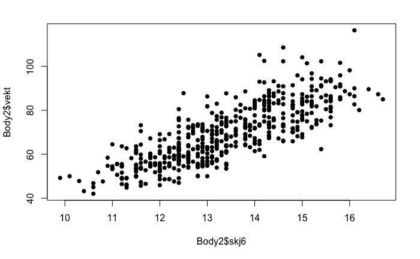

```r
plot(Body2$skj6,Body2$vekt,pch=16)
```

# OPPGAVE 4E)

```r
cor(Body2$skj1,Body2$vekt)
```

```
[1] 0.7251902
```

# Folgende kommando setter sammen (binder sammen) (“column-binding”, leser jeg inni meg)

# kolonnene vekt og de 9 forste colonnene i Body2, som er de 9 skjelettvariablene:

```r
vekt_og_skjelett <- cbind(Body2$vekt,Body2[,1:9])
cor(vekt_og_skjelett)
```

```
           Body2$vekt      skj1      skj2      skj3      skj4      skj5      skj6      skj7
Body2$vekt  1.0000000 0.7251902 0.4950085 0.6678749 0.8016512 0.8317228 0.8003596 0.7642507
skj1        0.7251902 1.0000000 0.3093432 0.4908040 0.5844052 0.7681418 0.7656135 0.7229092
skj2        0.4950085 0.3093432 1.0000000 0.6720331 0.3569032 0.3301081 0.3227419 0.2800661
skj3        0.6678749 0.4908040 0.6720331 1.0000000 0.4732554 0.5279424 0.5288549 0.4724727
skj4        0.8016512 0.5844052 0.3569032 0.4732554 1.0000000 0.6667497 0.6656682 0.6081920
skj5        0.8317228 0.7681418 0.3301081 0.5279424 0.6667497 1.0000000 0.7589745 0.7316923
skj6        0.8003596 0.7656135 0.3227419 0.5288549 0.6656682 0.7589745 1.0000000 0.8391840
skj7        0.7642507 0.7229092 0.2800661 0.4724727 0.6081920 0.7316923 0.8391840 1.0000000
skj8        0.7660177 0.6373857 0.4346772 0.6070260 0.5502577 0.6599966 0.7324671 0.7146803
skj9        0.7253441 0.6604441 0.3677858 0.4992125 0.5980714 0.6678250 0.8202454 0.7707234
                skj8      skj9
Body2$vekt 0.7660177 0.7253441
skj1       0.6373857 0.6604441
skj2       0.4346772 0.3677858
skj3       0.6070260 0.4992125
skj4       0.5502577 0.5980714
skj5       0.6599966 0.6678250
skj6       0.7324671 0.8202454
skj7       0.7146803 0.7707234
skj8       1.0000000 0.7248110
skj9       0.7248110 1.0000000
```

# Gjor det samme, men med litt ferre desimaler (runder av til 2 desimaler etter komma)

```r
round(cor(vekt_og_skjelett),2)
```

```
           Body2$vekt skj1 skj2 skj3 skj4 skj5 skj6 skj7 skj8 skj9
Body2$vekt       1.00 0.73 0.50 0.67 0.80 0.83 0.80 0.76 0.77 0.73
skj1             0.73 1.00 0.31 0.49 0.58 0.77 0.77 0.72 0.64 0.66
skj2             0.50 0.31 1.00 0.67 0.36 0.33 0.32 0.28 0.43 0.37
skj3             0.67 0.49 0.67 1.00 0.47 0.53 0.53 0.47 0.61 0.50
skj4             0.80 0.58 0.36 0.47 1.00 0.67 0.67 0.61 0.55 0.60
skj5             0.83 0.77 0.33 0.53 0.67 1.00 0.76 0.73 0.66 0.67
skj6             0.80 0.77 0.32 0.53 0.67 0.76 1.00 0.84 0.73 0.82
skj7             0.76 0.72 0.28 0.47 0.61 0.73 0.84 1.00 0.71 0.77
skj8             0.77 0.64 0.43 0.61 0.55 0.66 0.73 0.71 1.00 0.72
skj9             0.73 0.66 0.37 0.50 0.60 0.67 0.82 0.77 0.72 1.00
```

# Gjor det samme for omkretsvariablene:

```r
vekt_og_omkrets <- cbind(Body2$vekt,Body2[,10:21])
cor(vekt_og_omkrets)
```

```
           Body2$vekt     omkr1     omkr2     omkr3     omkr4     omkr5     omkr6     omkr7
Body2$vekt  1.0000000 0.8790112 0.8988030 0.9040587 0.7128129 0.7631658 0.5607090 0.8668781
omkr1       0.8790112 1.0000000 0.9271539 0.8242086 0.5176717 0.5344302 0.3256337 0.8954824
omkr2       0.8988030 0.9271539 1.0000000 0.8847985 0.6250592 0.5840322 0.3648410 0.9080543
omkr3       0.9040587 0.8242086 0.8847985 1.0000000 0.7554507 0.6922380 0.4235162 0.8060818
omkr4       0.7128129 0.5176717 0.6250592 0.7554507 1.0000000 0.8258085 0.6027844 0.5593449
omkr5       0.7631658 0.5344302 0.5840322 0.6922380 0.8258085 1.0000000 0.8299861 0.5606784
omkr6       0.5607090 0.3256337 0.3648410 0.4235162 0.6027844 0.8299861 1.0000000 0.4126912
omkr7       0.8668781 0.8954824 0.9080543 0.8060818 0.5593449 0.5606784 0.4126912 1.0000000
omkr8       0.8696797 0.8950894 0.8872642 0.7819858 0.4876314 0.5149025 0.3464281 0.9421877
omkr9       0.7960318 0.6245014 0.6138460 0.6584081 0.6133852 0.7360776 0.6403336 0.6205828
omkr10      0.7694480 0.6274995 0.6082365 0.6324246 0.5248565 0.6749092 0.6292662 0.6365035
omkr11      0.7630861 0.6797361 0.6688049 0.6565818 0.5229366 0.5807921 0.4264139 0.6690123
omkr12      0.8162352 0.8404832 0.8241905 0.7287236 0.4365170 0.4595271 0.2437586 0.8478348
               omkr8     omkr9    omkr10    omkr11    omkr12
Body2$vekt 0.8696797 0.7960318 0.7694480 0.7630861 0.8162352
omkr1      0.8950894 0.6245014 0.6274995 0.6797361 0.8404832
omkr2      0.8872642 0.6138460 0.6082365 0.6688049 0.8241905
omkr3      0.7819858 0.6584081 0.6324246 0.6565818 0.7287236
omkr4      0.4876314 0.6133852 0.5248565 0.5229366 0.4365170
omkr5      0.5149025 0.7360776 0.6749092 0.5807921 0.4595271
omkr6      0.3464281 0.6403336 0.6292662 0.4264139 0.2437586
omkr7      0.9421877 0.6205828 0.6365035 0.6690123 0.8478348
omkr8      1.0000000 0.6575134 0.6695164 0.7126974 0.9048649
omkr9      0.6575134 1.0000000 0.7968402 0.7383274 0.6405230
omkr10     0.6695164 0.7968402 1.0000000 0.7646407 0.6479390
omkr11     0.7126974 0.7383274 0.7646407 1.0000000 0.7526479
omkr12     0.9048649 0.6405230 0.6479390 0.7526479 1.0000000
```

```r
round(cor(vekt_og_omkrets),2)
```

```
           Body2$vekt omkr1 omkr2 omkr3 omkr4 omkr5 omkr6 omkr7 omkr8 omkr9 omkr10 omkr11 omkr12
Body2$vekt       1.00  0.88  0.90  0.90  0.71  0.76  0.56  0.87  0.87  0.80   0.77   0.76   0.82
omkr1            0.88  1.00  0.93  0.82  0.52  0.53  0.33  0.90  0.90  0.62   0.63   0.68   0.84
omkr2            0.90  0.93  1.00  0.88  0.63  0.58  0.36  0.91  0.89  0.61   0.61   0.67   0.82
omkr3            0.90  0.82  0.88  1.00  0.76  0.69  0.42  0.81  0.78  0.66   0.63   0.66   0.73
omkr4            0.71  0.52  0.63  0.76  1.00  0.83  0.60  0.56  0.49  0.61   0.52   0.52   0.44
omkr5            0.76  0.53  0.58  0.69  0.83  1.00  0.83  0.56  0.51  0.74   0.67   0.58   0.46
omkr6            0.56  0.33  0.36  0.42  0.60  0.83  1.00  0.41  0.35  0.64   0.63   0.43   0.24
omkr7            0.87  0.90  0.91  0.81  0.56  0.56  0.41  1.00  0.94  0.62   0.64   0.67   0.85
omkr8            0.87  0.90  0.89  0.78  0.49  0.51  0.35  0.94  1.00  0.66   0.67   0.71   0.90
omkr9            0.80  0.62  0.61  0.66  0.61  0.74  0.64  0.62  0.66  1.00   0.80   0.74   0.64
omkr10           0.77  0.63  0.61  0.63  0.52  0.67  0.63  0.64  0.67  0.80   1.00   0.76   0.65
omkr11           0.76  0.68  0.67  0.66  0.52  0.58  0.43  0.67  0.71  0.74   0.76   1.00   0.75
omkr12           0.82  0.84  0.82  0.73  0.44  0.46  0.24  0.85  0.90  0.64   0.65   0.75   1.00
```